# Estadística Avanzada: A1 - Preprocesado de Datos

cperezceb - Carlos Pérez Cebrián

Marzo 2022

# A1 - Preprocesado de Datos

En esta actividad realizaremos el preprocesado de un fichero de datos que contiene información de una muestra extraída a partir de un censo, en el que para cada persona, se registran los salarios aparte de información personal adicional. El conjunto de datos contiene 32,560 registros y 14 variables. Los datos se han extraído y modificado parcialmente (por motivos académicos) de la base de datos disponible en la web Machine Learning Repository: https://archive.ics.uci.edu/ml/datasets/Adult.

## Cargar el archivo

Cargar el archivo de datos y examinar el tipo de datos con los que R ha interpretado cada variable. Examinar también los valores resumen de cada tipo de variable.

Instalamos y cargamos la librerias.

```r
# https://cran.r-project.org/web/packages/ggplot2/index.html
if (!require('ggplot2')) install.packages('ggplot2'); library('ggplot2')
# https://cran.r-project.org/web/packages/dplyr/index.html
if (!require('dplyr')) install.packages('dplyr'); library('dplyr')
# https://cran.r-project.org/web/packages/dplyr/index.html
if (!require('tidyverse')) install.packages('tidyverse'); library('tidyverse')
# https://cran.rstudio.com/bin/windows/contrib/4.0/gridExtra_2.3.zip
if (!require('gridExtra')) install.packages('gridExtra'); library(gridExtra)
```

Cargamos en la variable *DatosCenso* el fichero proporcionado .

```r
DatosCenso <- read.csv2(file="CensusIncomedataset.csv", header=TRUE, sep=";", dec=".", stringsAsFactors = FALSE);
```

Revisamos su estructura.

- Tamaño de la muestra.
- Número de variables disponibles
- Tipo de datos (texto, numérico, fecha)

```r
str(DatosCenso)
```

```
## 'data.frame':    32560 obs. of  14 variables:
##  $ CS_ID         : chr  "CS1" "CS2" "CS3" "CS4" ...
##  $ age           : int  50 38 53 28 37 49 52 31 42 37 ...
##  $ workclass     : chr  " Self-Employed" " Private" " Private" " Private" ...
##  $ fnlwgt        : int  77516 83311 215646 234721 338409 284582 160187 209642 45781 159449 ...
##  $ education_num : int  13 9 7 13 14 5 9 14 13 10 ...
##  $ marital_status: chr  " Married" " Divorced" " Married" " Married" ...
##  $ relationship  : chr  "Not-in-family" "Husband" "Not-in-family" "Husband" ...
##  $ occupation    : chr  " White-Collar" " Blue-Collar" " Blue-Collar" " Professional" ...
##  $ race          : chr  " White" " White" " Black" " Black" ...
##  $ sex           : chr  " M" " M" " M" " Fem" ...
##  $ capital_gain  : int  2174 0 0 0 0 0 0 0 14084 5178 ...
##  $ capital_loss  : int  0 0 0 0 0 0 0 0 0 0 ...
##  $ hours_per_week: chr  "13,5 h" "40 h" "40,5 h" "40 h" ...
##  $ income        : chr  "2000,3 Milers d'euros" "51,67 Milers d'euros" "50,08 Milers d'euros" "44,21 Milers d'euros" ...
```

Veamos una pequeña muestra del conjunto de datos a estudio.

```r
head(DatosCenso,6)
```

```
##   CS_ID age      workclass fnlwgt education_num marital_status  relationship
## 1   CS1  50  Self-Employed  77516            13        Married Not-in-family
## 2   CS2  38        Private  83311             9       Divorced       Husband
## 3   CS3  53        Private 215646             7        Married Not-in-family
## 4   CS4  28        Private 234721            13        Married       Husband
## 5   CS5  37        Private 338409            14        Married          Wife
## 6   CS6  49        Private 284582             5        Married          Wife
##      occupation   race  sex capital_gain capital_loss hours_per_week
## 1  White-Collar  White    M         2174            0         13,5 h
## 2   Blue-Collar  White    M            0            0           40 h
## 3   Blue-Collar  Black    M            0            0         40,5 h
## 4  Professional  Black  Fem            0            0           40 h
## 5  White-Collar  White  Fem            0            0         40,5 h
## 6       Service  Black  Fem            0            0           16 h
##                  income
## 1 2000,3 Milers d'euros
## 2  51,67 Milers d'euros
## 3  50,08 Milers d'euros
## 4  44,21 Milers d'euros
## 5    0,1 Milers d'euros
## 6  43,93 Milers d'euros
```

- Datos de la muestra:
  - **CS_ID**: Identificador del individuo.
  - **age**: Edad del individuo.
  - **workclass**: Categorización del individuo en base al perfil laboral.
  - **fnlwgt**: Numero de unidades de la población objetivo que representa la unidad respondiente.
  - **education_num**: Numero de años de formación educativa del individuo.
  - **marital_status**: Estado civil del individuo.
  - **occupation**: Categorización del individuo en base a la tipologia del trabajo.
  - **relationship**: Parentesco de la unidad que responde de la familia.
  - **race**: Grupo racial al que pertenece el individuo.
  - **sex**: Genero del individuo.
  - **capital_gain**: Dineros ganados por inversión del individuo.
  - **capital_loss**: Dineros perdidos por inversión del individuo.
  - **hours_per_week**: Horas por semana trabajadas por el individuo.
  - **income**: Salario (anual) del individuo.

Sacamos algunas estadísticas sobre los datos para hacernos una idea de cómo son.

```r
print(summary(DatosCenso))
```

```
##     CS_ID                age          workclass             fnlwgt
##  Length:32560       Min.   : 17.00   Length:32560       Min.   :  12285
##  Class :character   1st Qu.: 28.00   Class :character   1st Qu.: 117824
##  Mode  :character   Median : 37.00   Mode  :character   Median : 178356
##                     Mean   : 38.58                      Mean   : 189775
##                     3rd Qu.: 48.00                      3rd Qu.: 237046
##                     Max.   :650.00                      Max.   :1484705
##                     NA's   :7
##  education_num   marital_status     relationship        occupation
##  Min.   : 1.00   Length:32560       Length:32560       Length:32560
##  1st Qu.: 9.00   Class :character   Class :character   Class :character
##  Median :10.00   Mode  :character   Mode  :character   Mode  :character
##  Mean   :10.08
##  3rd Qu.:12.00
##  Max.   :16.00
##  NA's   :7
##      race               sex             capital_gain    capital_loss
##  Length:32560       Length:32560       Min.   :    0   Min.   :   0.00
##  Class :character   Class :character   1st Qu.:    0   1st Qu.:   0.00
##  Mode  :character   Mode  :character   Median :    0   Median :   0.00
##                                        Mean   : 1077   Mean   :  87.31
##                                        3rd Qu.:    0   3rd Qu.:   0.00
##                                        Max.   :99999   Max.   :4356.00
##
##  hours_per_week        income
##  Length:32560       Length:32560
##  Class :character   Class :character
##  Mode  :character   Mode  :character
##
##
##
##
```

## Obtención del dataset para realizar el estudio

En esta fase se seleccionan los registros y/o variables que se utilizarán para realizar el estudio. En muchas ocasiones, no se trabaja con todo el dataset disponible ya que existen variables y/o registros de control o que no es necesario usar para el estudio concreto que se quiere realizar.

En este caso, se quieren eliminar las variables fnlwgt, capital_gain y capital_loss además de los registros con más de 5 valores NAs.

Por otra parte, se pueden crear nuevas variables en función de las disponibles. En este caso, se creará la variable education_cat que categoriza la formación académica en formación primaria si education_num es menor de 7 años, secundaria si education_num está entre 7 y 9 años, universitaria si education_num esta entre 10 y 13 años y postuniversitaria si education_num es mayor de 13 años.

Por último, se quiere cambiar el nombre de la variable sex por gender.

Descartamos las variables *fnlwgt, capital_gain y capital_loss* que no son objeto de estudio

```r
DatosCenso$fnlwgt <- NULL
DatosCenso$capital_gain <- NULL
DatosCenso$capital_loss <- NULL
```

Revisamos los episodios con valores nulos y eliminamos los registros con 5 valores NAs

```r
DescartarValoresNa <- function(Datos, n=0) {
  Datos[rowSums(is.na(Datos)) <= n,]
}

DatosCenso <- DescartarValoresNa(DatosCenso,5)
```

Tras estas operaciones sobre nuestro conjunto de datos, la variable *DatosCenso* queda de la siguiente forma:

```
## [1] "Tamaño de la muestra es: 32553 y contiene 11 variables."
```

Creamos la variable *education_cat* que identificará el nivel de estudios y puede tener los siguientes valores:

- primaria, estudios inferiores a 7 años
- secundaria, estudios comprendidos entre 7 y 9 años
- universitaria, estudios comprendidos entre 10 y 13 años.
- postuniversitaria, estudios de más de 13 años.

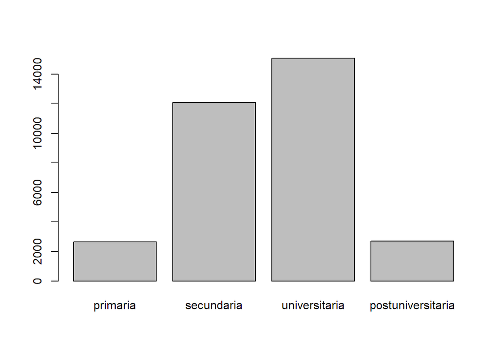

```r
# Valor por defecto
DatosCenso$education_cat<-'primaria'
DatosCenso$education_cat<- cut(DatosCenso$education_num, breaks=c(0,6,9,13,100),labels=c('primaria','secundaria','universitaria','postuniversitaria'))

# Representamos gráficamente los valores de la nueva variable
plot(DatosCenso$education_cat)
```

Por último, cambiamos el nombre de la variable *sex* por *gender*.

```r
names(DatosCenso)[names(DatosCenso)=='sex']<-'gender'
```

Revisamos los datos de la variable de *gender*

```r
table(DatosCenso$gender)
```

```
##
##       F     Fem  female  Female       m       M    male    Male
##     500     400    1100    8767     499     400    1100   19787
```

## Duplicación de códigos

Verificad la consistencia en la variable CS_ID. Si existen registros duplicados, asignad un nuevo código para evitar códigos duplicados. El nuevo código debe ser un valor no usado (valores superiores al máximo valor numérico contenido en CS_ID). Conservad el mismo formato que el resto de códigos, con “CS” delante de la secuencia numérica. Podéis usar la función duplicated de R para detectar los duplicados.

Comprobamos, para la variabla *CS_ID*, cuantos valores únicos tiene y comparamos con el total de registros.

```r
#Obtener los valores repetidos para la variable CS_ID
duplicados <- unique(DatosCenso[duplicated(DatosCenso$CS_ID, fromLast=TRUE),])
table(duplicados$CS_ID)
```

```
##
## CS23654   CS624  CS7163  CS7453  CS8017  CS8087  CS9197
##       1       1       1       1       1       1       1
```

```r
#Obtener el valor máximo para generar los nuevos índices.
indices<-gsub("CS","",DatosCenso$CS_ID)
indice_max <- max(as.numeric(indices))


#actualizar los identificadores duplicados con los nuevos valores.
for(i in 1:dim(duplicados)[1])
{
    indice_max<- indice_max+1
    indice_next <- paste0('CS',indice_max)

    row_index<- which.max(DatosCenso$CS_ID==duplicados[i,]$CS_ID)
    DatosCenso[row_index,]$CS_ID<-indice_next
}

#Comprobación: Obtener los valores repetidos para la variable CS_ID
duplicados <- unique(DatosCenso[duplicated(DatosCenso$CS_ID, fromLast=TRUE),])
table(duplicados$CS_ID)
```

```
## < table of extent 0 >
```

## Normalización de los datos cualitativos

### Eliminación de espacios en blanco

Se ha observado que existen espacios en blanco al inicio de los valores en las variables cualitativas. Por tanto, es necesario eliminar estos espacios en blancos.

Utilizaremos la función *trimws* para limpiar los espacios en blanco de las variables categóricas.

```r
for(i in colnames(DatosCenso))
{
  if(class(DatosCenso[[i]])=="character")
  {
    DatosCenso[[i]]<-trimws(DatosCenso[[i]], which=c("both", "left", "right"))
    # print(paste0("Columna: ", i , " Tipo de la columna: ", class(DatosCenso[[i]]) ))
  }
}
```

### Marital-Status

Cambiar las categorías de la variable marital status actuales por otras que ocupen un carácter. Los valores que se asignaron a la variable marital_status son: M por Married, S por Single, X por Separated, D por Divorced, W por Widowed. Representad gráficamente la distribución de los valores de la variable.

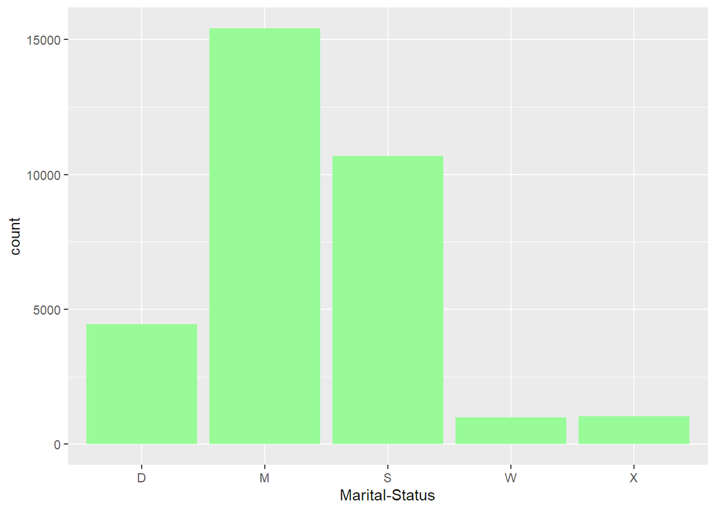

```r
DatosCenso$marital_status[DatosCenso$marital_status == "Married"]  <- "M"

DatosCenso$marital_status[DatosCenso$marital_status == "Single"]   <- "S"

DatosCenso$marital_status[DatosCenso$marital_status =="Separated"] <- "X"

DatosCenso$marital_status[DatosCenso$marital_status =="Divorced"]  <- "D"

DatosCenso$marital_status[DatosCenso$marital_status =="Widowed"]   <- "W"


ggplot(DatosCenso, aes(x=marital_status)) + geom_bar(fill="palegreen") + labs(x="Marital-Status")
```

```r
table(DatosCenso$marital_status)
```

```
##
##     D     M     S     W     X
##  4442 15413 10680   993  1025
```

### Género

Revisad la consistencia de los valores de la variable gender y realice las modificaciones oportunas para indicar las categorías finales como f y m que corresponde a femeníno y masculíno, respectivamente.

Representad gráficamente la distribución de los valores de la variable.

Revisamos los datos que contiene la variable *gender*

```r
table(DatosCenso$gender)
```

```
##
##      F    Fem female Female      m      M   male   Male
##    500    400   1100   8767    499    400   1100  19787
```

Actualizamos para contener sólo dos valores: f - femeníno y m - masculíno

```r
# caso01: f - femeníno (contiene una "f")
DatosCenso$gender[grepl("[fF]+",DatosCenso$gender)]<-"f"

# caso02: m - masculino (contiene una "m")
DatosCenso$gender[grepl("[mM]+",DatosCenso$gender)]<-"m"
```

Representamos gráficamente para ver como queda la variable

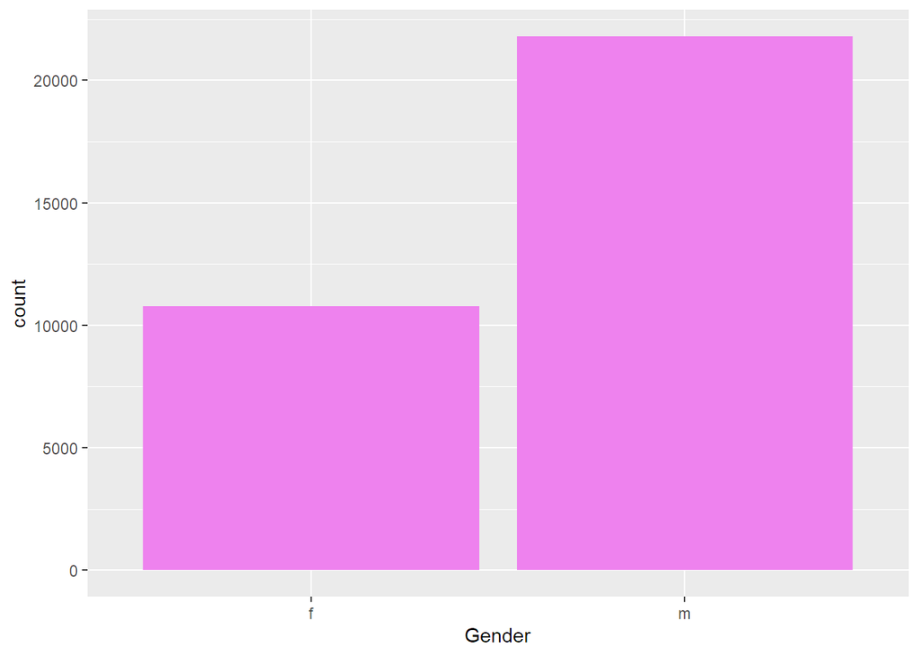

```r
# Representamos gráficamente la variable
ggplot(DatosCenso, aes(x=gender)) + geom_bar(fill="violet") + labs(x="Gender")
```

## Normalización de los datos cuantitativos

Inspeccionar los valores de los datos cuantitativos y realizar las normalizaciones oportunas siguiendo los criterios especificados anteriormente. Estas normalizaciones tienen como objetivo uniformizar los formatos. Si hay valores perdidos o valores extremos, se tratarán más adelante. Al realizar estas normalizaciones, se debe demostrar que la normalización sobre cada variable ha dado el resultado esperado. Por lo tanto, se recomienda mostrar un fragmento del archivo de datos resultante. Para evitar mostrar todo el conjunto de datos, se puede mostrar una parte del mismo, con las funciones head y/o tail. Seguid el orden de los apartados.

### Edad

Revisad el formato de la variable age y realizad las transformaciones oportunas según los criterios especificados anteriormente. Si existen valores atípicos, se tratarán más adelante.

Evaluamos la variable *edad* antes de aplicar la normalización

```r
 summary(DatosCenso$age)
```

```
##    Min. 1st Qu.  Median    Mean 3rd Qu.    Max.
##   17.00   28.00   37.00   38.58   48.00  650.00
```

Detectamos que el dataset contiene datos erróneos, el valor máximo de la variable edad es 650. Normalizamos la variable, aplicamos la siguiente fórmula

$$Normalización = \frac{X - min(X)}{ max(X) - min(X)}$$

```r
 DatosCenso$age<-(DatosCenso$age - min(DatosCenso$age)) / (max(DatosCenso$age) - min(DatosCenso$age))
 # DatosCenso$age <- (DatosCenso$age - mean(DatosCenso$age)) / sd (DatosCenso$age)

 # mean(DatosCenso$age)
 # sd(DatosCenso$age)
 summary(DatosCenso$age)
```

```
##    Min. 1st Qu.  Median    Mean 3rd Qu.    Max.
## 0.00000 0.01738 0.03160 0.03410 0.04897 1.00000
```

Obtenemos valores comprendidos entre 0 y 1. Veamos una pequeña muestra de nuestra muestra.

```r
 head(DatosCenso,6)
```

```
##   CS_ID        age     workclass education_num marital_status  relationship
## 1   CS1 0.05213270 Self-Employed            13              M Not-in-family
## 2   CS2 0.03317536       Private             9              D       Husband
## 3   CS3 0.05687204       Private             7              M Not-in-family
## 4   CS4 0.01737757       Private            13              M       Husband
## 5   CS5 0.03159558       Private            14              M          Wife
## 6   CS6 0.05055292       Private             5              M          Wife
##     occupation  race gender hours_per_week                income
## 1 White-Collar White      m         13,5 h 2000,3 Milers d'euros
## 2  Blue-Collar White      m           40 h  51,67 Milers d'euros
## 3  Blue-Collar Black      m         40,5 h  50,08 Milers d'euros
## 4 Professional Black      f           40 h  44,21 Milers d'euros
## 5 White-Collar White      f         40,5 h    0,1 Milers d'euros
## 6      Service Black      f           16 h  43,93 Milers d'euros
##       education_cat
## 1     universitaria
## 2        secundaria
## 3        secundaria
## 4     universitaria
## 5 postuniversitaria
## 6          primaria
```

### Educación

Revisad el formato de la variable education_num y realizad las transformaciones oportunas según los criterios especificados anteriormente. Si existen valores atípicos, se tratarán más adelante.

```r
summary(DatosCenso$education_num)
```

```
##    Min. 1st Qu.  Median    Mean 3rd Qu.    Max.
##    1.00    9.00   10.00   10.08   12.00   16.00
```

La mayoria de los valores se encuentran comprendidos entre 9 y 12, corresponde a un grado de educación de secundaria y universitaria respectivamente.

Normalizamos aplicando la fórmula vista en el apartado anterior

```r
 DatosCenso$education_num<-(DatosCenso$education_num - min(DatosCenso$education_num)) / (max(DatosCenso$education_num) - min(DatosCenso$education_num))

 summary(DatosCenso$education_num)
```

```
##    Min. 1st Qu.  Median    Mean 3rd Qu.    Max.
##  0.0000  0.5333  0.6000  0.6054  0.7333  1.0000
```

Obtenemos valores comprendidos entre 0 y 1. Veamos una pequeña muestra de nuestra muestra.

```r
 head(DatosCenso,6)
```

```
##   CS_ID        age     workclass education_num marital_status  relationship
## 1   CS1 0.05213270 Self-Employed     0.8000000              M Not-in-family
## 2   CS2 0.03317536       Private     0.5333333              D       Husband
## 3   CS3 0.05687204       Private     0.4000000              M Not-in-family
## 4   CS4 0.01737757       Private     0.8000000              M       Husband
## 5   CS5 0.03159558       Private     0.8666667              M          Wife
## 6   CS6 0.05055292       Private     0.2666667              M          Wife
##     occupation  race gender hours_per_week                income
## 1 White-Collar White      m         13,5 h 2000,3 Milers d'euros
## 2  Blue-Collar White      m           40 h  51,67 Milers d'euros
## 3  Blue-Collar Black      m         40,5 h  50,08 Milers d'euros
## 4 Professional Black      f           40 h  44,21 Milers d'euros
## 5 White-Collar White      f         40,5 h    0,1 Milers d'euros
## 6      Service Black      f           16 h  43,93 Milers d'euros
##       education_cat
## 1     universitaria
## 2        secundaria
## 3        secundaria
## 4     universitaria
## 5 postuniversitaria
## 6          primaria
```

### Horas por semana

Revisad el formato de la variable hours_per_week y realizad las transformaciones oportunas según los criterios especificados anteriormente. Si existen valores atípicos, se tratarán más adelante.

```r
str(DatosCenso$hours_per_week)
```

```
##  chr [1:32553] "13,5 h" "40 h" "40,5 h" "40 h" "40,5 h" "16 h" "45 h" ...
```

La variable es de tipo *character* y representa el número de horas trabajadas por semana. En primer lugar, trabajaremos para transformar la variable a un tipo de datos numérico.

```r
DatosCenso$hours_per_week<-gsub(" h","",DatosCenso$hours_per_week)
DatosCenso$hours_per_week<-gsub(",",".",DatosCenso$hours_per_week)
DatosCenso$hours_per_week<-as.numeric(DatosCenso$hours_per_week)
```

Normalizamos del mismo modo que las variables *Educación* y *Edad*

```r
DatosCenso$hours_per_week<- (DatosCenso$hours_per_week - min(DatosCenso$hours_per_week))/(max(DatosCenso$hours_per_week)-min(DatosCenso$hours_per_week))

summary(DatosCenso$hours_per_week)
```

```
##    Min. 1st Qu.  Median    Mean 3rd Qu.    Max.
##  0.0000  0.3959  0.4010  0.4032  0.4518  1.0000
```

Obtenemos valores comprendidos entre 0 y 1. Veamos una pequeña muestra de nuestra muestra.

```r
 head(DatosCenso,6)
```

```
##   CS_ID        age     workclass education_num marital_status  relationship
## 1   CS1 0.05213270 Self-Employed     0.8000000              M Not-in-family
## 2   CS2 0.03317536       Private     0.5333333              D       Husband
## 3   CS3 0.05687204       Private     0.4000000              M Not-in-family
## 4   CS4 0.01737757       Private     0.8000000              M       Husband
## 5   CS5 0.03159558       Private     0.8666667              M          Wife
## 6   CS6 0.05055292       Private     0.2666667              M          Wife
##     occupation  race gender hours_per_week                income
## 1 White-Collar White      m      0.1269036 2000,3 Milers d'euros
## 2  Blue-Collar White      m      0.3959391  51,67 Milers d'euros
## 3  Blue-Collar Black      m      0.4010152  50,08 Milers d'euros
## 4 Professional Black      f      0.3959391  44,21 Milers d'euros
## 5 White-Collar White      f      0.4010152    0,1 Milers d'euros
## 6      Service Black      f      0.1522843  43,93 Milers d'euros
##       education_cat
## 1     universitaria
## 2        secundaria
## 3        secundaria
## 4     universitaria
## 5 postuniversitaria
## 6          primaria
```

### Income

Revisad el formato de la variable income y realizad las transformaciones oportunas según los criterios especificados anteriormente. Si existen valores atípicos, se tratarán más adelante.

```r
str(DatosCenso$income)
```

```
##  chr [1:32553] "2000,3 Milers d'euros" "51,67 Milers d'euros" ...
```

Del mismo modo que para la variable horas trabajadas por semana, nos encontramos con una variable de tipo *character* que debemos transformar a numérica. Primero preparamos la variable, la convertimos a numérica y por último normalizamos.

Encontramos medidas expresadas en miles de euros y otras expresada en euros.

```r
#creamos una variable factor para la conversión de unidades de medida [euro - miles de euro]
DatosCenso$factor <-1
DatosCenso$factor[str_detect(DatosCenso$income, "Milers d'euros")]<-1000

#limpiar la variable de tipo string para transformarla en numérica
DatosCenso$income <- gsub(" Milers d'euros","",DatosCenso$income)
DatosCenso$income <- gsub(" euros","",DatosCenso$income)
DatosCenso$income <- gsub(",",".",DatosCenso$income)
DatosCenso$income <- as.numeric(DatosCenso$income)

#aplicamos la equivalencia entre unidades
DatosCenso$income <- DatosCenso$income * DatosCenso$factor
DatosCenso$factor<-NULL
```

Normalizamos los datos

```r
DatosCenso$income <- (DatosCenso$income - min(DatosCenso$income))/(max(DatosCenso$income)-min(DatosCenso$income))

summary(DatosCenso$income)
```

```
##    Min. 1st Qu.  Median    Mean 3rd Qu.    Max.
## 0.00000 0.02020 0.02324 0.02285 0.02540 1.00000
```

Obtenemos valores comprendidos entre 0 y 1. Veamos una pequeña muestra de nuestra muestra.

```r
 head(DatosCenso,6)
```

```
##   CS_ID        age     workclass education_num marital_status  relationship
## 1   CS1 0.05213270 Self-Employed     0.8000000              M Not-in-family
## 2   CS2 0.03317536       Private     0.5333333              D       Husband
## 3   CS3 0.05687204       Private     0.4000000              M Not-in-family
## 4   CS4 0.01737757       Private     0.8000000              M       Husband
## 5   CS5 0.03159558       Private     0.8666667              M          Wife
## 6   CS6 0.05055292       Private     0.2666667              M          Wife
##     occupation  race gender hours_per_week     income     education_cat
## 1 White-Collar White      m      0.1269036 0.93708128     universitaria
## 2  Blue-Collar White      m      0.3959391 0.02416022        secundaria
## 3  Blue-Collar Black      m      0.4010152 0.02341532        secundaria
## 4 Professional Black      f      0.3959391 0.02066526     universitaria
## 5 White-Collar White      f      0.4010152 0.00000000 postuniversitaria
## 6      Service Black      f      0.1522843 0.02053408          primaria
```

## Valores atípicos

Revisad si hay valores atípicos en las variables age, education_num, hours_per_week y income. Si se trata de un valor anómalo, es decir anormalmente alto o bajo, substituir su valor por NA y posteriormente, se imputará.

```r
summary(DatosCenso[, c("age","education_num","hours_per_week","income")])
```

```
##       age          education_num    hours_per_week       income
##  Min.   :0.00000   Min.   :0.0000   Min.   :0.0000   Min.   :0.00000
##  1st Qu.:0.01738   1st Qu.:0.5333   1st Qu.:0.3959   1st Qu.:0.02020
##  Median :0.03160   Median :0.6000   Median :0.4010   Median :0.02324
##  Mean   :0.03410   Mean   :0.6054   Mean   :0.4032   Mean   :0.02285
##  3rd Qu.:0.04897   3rd Qu.:0.7333   3rd Qu.:0.4518   3rd Qu.:0.02540
##  Max.   :1.00000   Max.   :1.0000   Max.   :1.0000   Max.   :1.00000
```

### Age

Según los datos resumidos de la tabla anterior, observamos una gran diferencia entre el valor del 3er cuartil y el valor máximo.

Veamos su representación gráfica

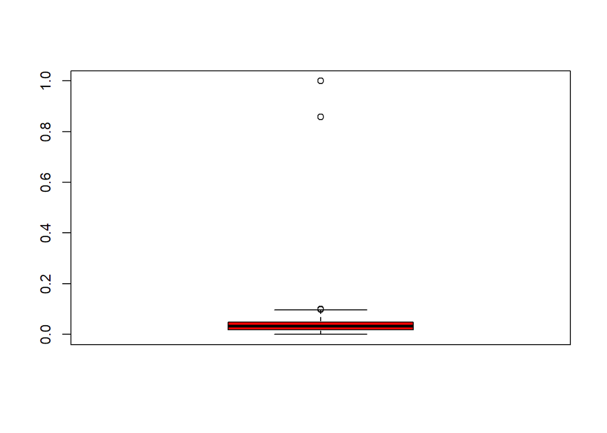

```r
boxplot(DatosCenso$age, col = "red")
```

En primer lugar, calculamos los límite que nos serviran para descarta los valores atípicos. Nos basaremos en los valores del 1er y 3er cuartil y los calcularemos de la siguiente forma:

*Nivel inferior*

$$q < Q_1 - 1.5*IQR$$
*Nivel superior*

$$q > Q_3 + 1.5*IQR$$
Es decir, consideramos atípico aquello que se encuentra a 1.5 veces de uno de los cuartiles. Calculamos y aplicamos la transformación.

```r
primer_cuartil<-quantile(DatosCenso$age, prob = 0.25)
tercer_cuartil<-quantile(DatosCenso$age, prob = 0.75)
rango_intercuartilico<-IQR(DatosCenso$age)

menoresDe <- primer_cuartil - (1.5*rango_intercuartilico)
mayoresDe <- tercer_cuartil + (1.5*rango_intercuartilico)

DatosCenso$age[DatosCenso$age<menoresDe]<-NA
DatosCenso$age[DatosCenso$age>mayoresDe]<-NA

summary(DatosCenso$age)
```

```
##    Min. 1st Qu.  Median    Mean 3rd Qu.    Max.    NA's
## 0.00000 0.01738 0.03160 0.03396 0.04897 0.09637      44
```

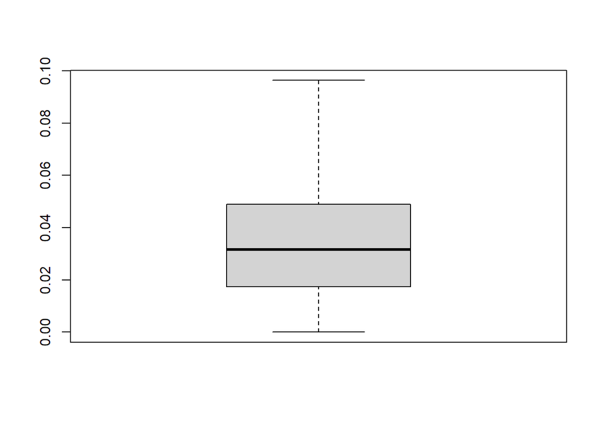

```r
boxplot(DatosCenso$age)
```

### education_num

Veamos la representación gráfica de la variable *education_num*

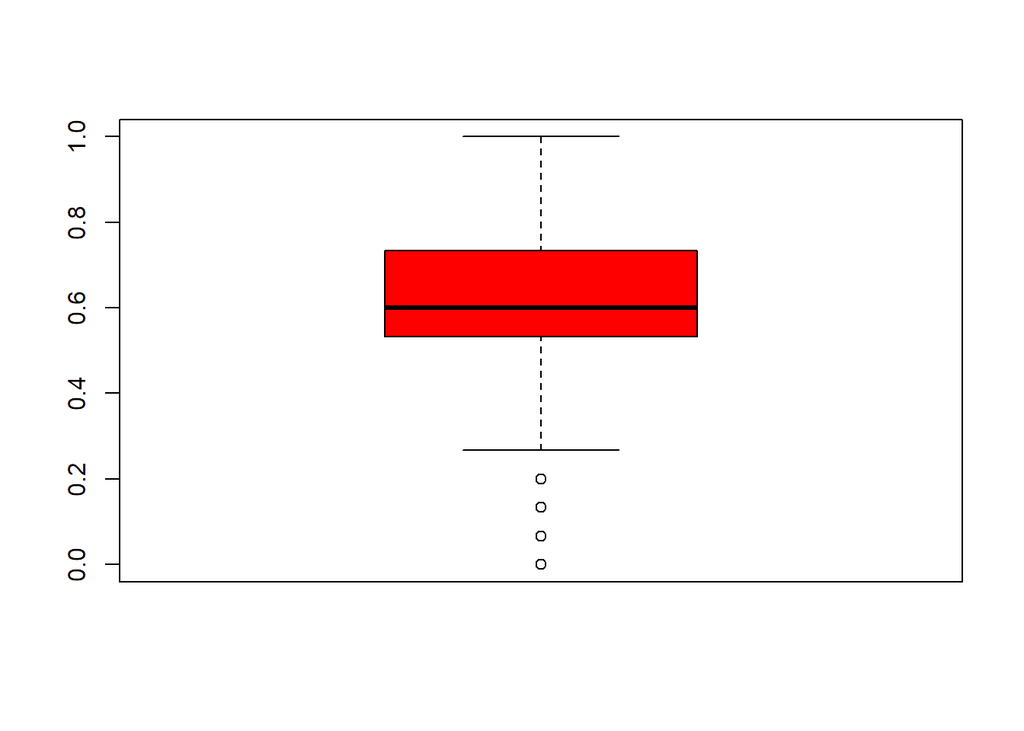

```r
boxplot(DatosCenso$education_num, col = "red")
```

En esta ocasión los valores atípicos los encontramos por debajo del límite inferior. Actualizaremos su valor con el valor *NA*.

Actuamos de la misma forma que con la variable *age*; calculamos los límites y descartamos valores atípicos.

```r
primer_cuartil<-quantile(DatosCenso$education_num, prob = 0.25)
tercer_cuartil<-quantile(DatosCenso$education_num, prob = 0.75)
rango_intercuartilico<-IQR(DatosCenso$education_num)

menoresDe <- primer_cuartil - (1.5*rango_intercuartilico)
mayoresDe <- tercer_cuartil + (1.5*rango_intercuartilico)

DatosCenso$education_num[DatosCenso$education_num<menoresDe]<-NA
DatosCenso$education_num[DatosCenso$education_num>mayoresDe]<-NA

summary(DatosCenso$education_num)
```

```
##    Min. 1st Qu.  Median    Mean 3rd Qu.    Max.    NA's
##  0.2667  0.5333  0.6000  0.6226  0.8000  1.0000    1197
```

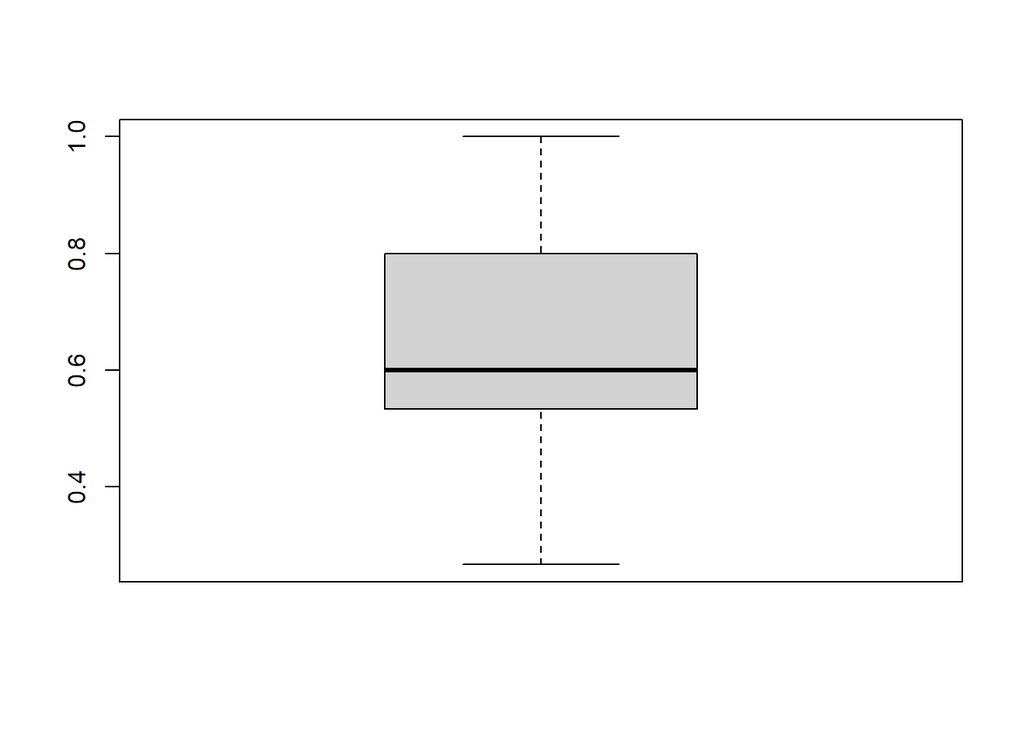

```r
boxplot(DatosCenso$education_num)
```

### hours_per_week

Veamos la representación gráfica de la variable *hours_per_week* y el valor de los percentiles.

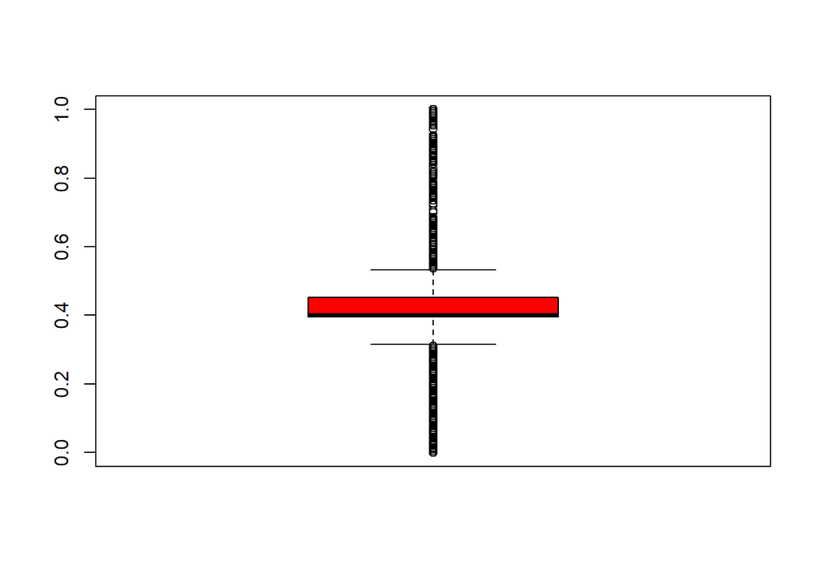

```r
boxplot(DatosCenso$hours_per_week, col = "red")
```

Observamos *outliers* tanto por el límite superior como por el límite inferior

```r
primer_cuartil<-quantile(DatosCenso$hours_per_week, prob = 0.25)
tercer_cuartil<-quantile(DatosCenso$hours_per_week, prob = 0.75)
rango_intercuartilico<-IQR(DatosCenso$hours_per_week)

menoresDe <- primer_cuartil - (1.5*rango_intercuartilico)
mayoresDe <- tercer_cuartil + (1.5*rango_intercuartilico)

DatosCenso$hours_per_week[DatosCenso$hours_per_week<menoresDe]<-NA
DatosCenso$hours_per_week[DatosCenso$hours_per_week>mayoresDe]<-NA

summary(DatosCenso$hours_per_week)
```

```
##    Min. 1st Qu.  Median    Mean 3rd Qu.    Max.    NA's
##   0.315   0.396   0.401   0.414   0.421   0.533    8715
```

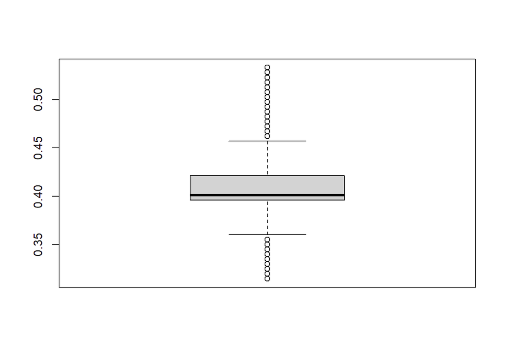

```r
boxplot(DatosCenso$hours_per_week)
```

### income

La datos resumidos de la variable indican que el valor del tercer cuartil es 0,025 y el valor máximo 1. Procedemos del mismo modo que en los apartados anteriores.

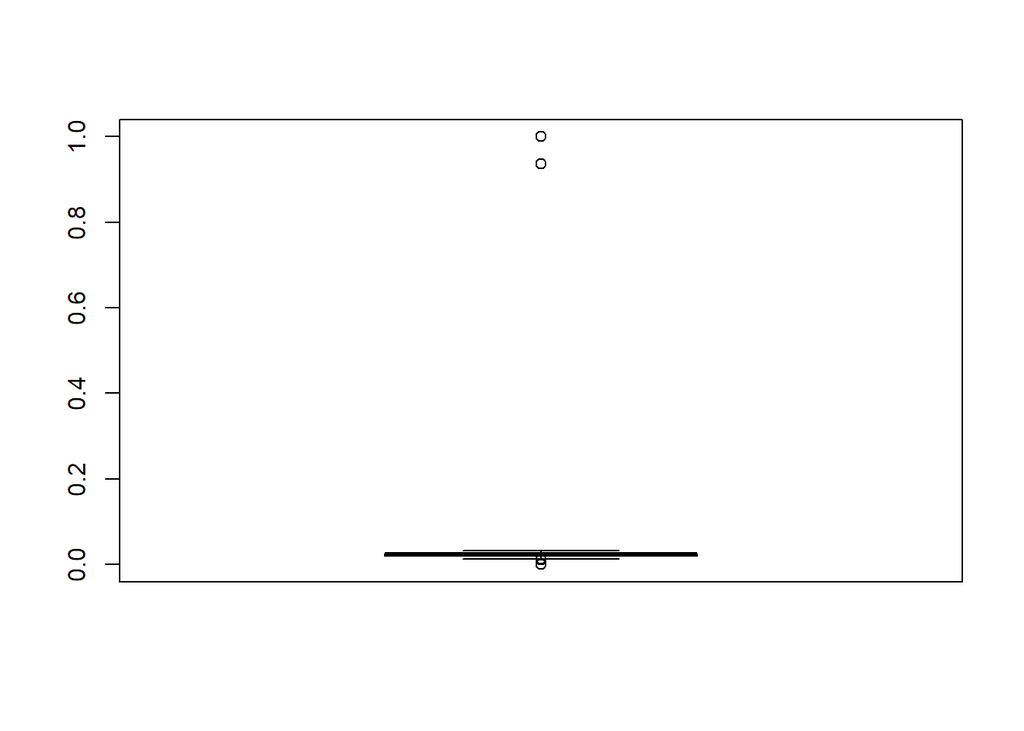

```r
boxplot(DatosCenso$income, col = "red")
```

```r
# DatosCenso$income[DatosCenso$income>0.037]<-NA
# DatosCenso$income[DatosCenso$income<0.01]<-NA

primer_cuartil<-quantile(DatosCenso$income, prob = 0.25)
tercer_cuartil<-quantile(DatosCenso$income, prob = 0.75)
rango_intercuartilico<-IQR(DatosCenso$income)

menoresDe <- primer_cuartil - (1.5*rango_intercuartilico)
mayoresDe <- tercer_cuartil + (1.5*rango_intercuartilico)

DatosCenso$income[DatosCenso$income<menoresDe]<-NA
DatosCenso$income[DatosCenso$income>mayoresDe]<-NA
```

Representación gráfica de como han quedado las variables tras revisar los datos anómalos

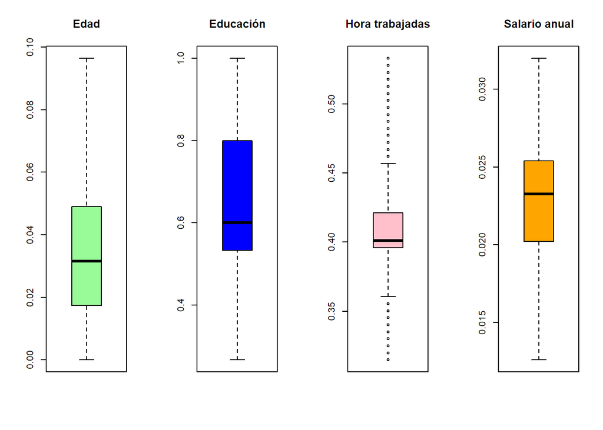

```r
par(mfrow = c(1,4)) #parámetros globales para los plots --> cómo se distribuyen los gráficos (1 fila, 4 columnas)
with(DatosCenso,
     {
       boxplot(age,            col = "palegreen", main="Edad")
       boxplot(education_num,  col = "blue",      main="Educación")
       boxplot(hours_per_week, col = "pink",      main="Hora trabajadas")
       boxplot(income,         col = "orange",    main="Salario anual")
     })
```

## Imputación de valores

Buscad si existen valores perdidos en las variables cuantitativas age, education_num, hours_per_week y income.

En caso de valores perdidos, aplicad el proceso siguiente:

- Para ’age‘, aplicad imputación por la media aritmética.
- Para ’income‘, aplicar imputación por la media aritmética de los registros del mismo género, es decir, separado por género.
- En el resto de variables, aplicad imputación por vecinos más cercanos, usando la distancia de Gower, considerando en el cómputo de los vecinos más cercanos el resto de variables cuantitativas mencionadas en este apartado. Además, considerad que la imputación debe hacerse con registros del mismo género. Por ejemplo, si un registro a imputar es de género “M”, se debe realizar la imputación usando las variables cuantitativas de los registros de género “M”. Para realizar esta imputación, podéis usar la función “kNN” de la librería VIM con un número de vecinos igual a 11. Mostrad que la imputación se ha realizado correctamente, mostrando el resultado de los datos afectados por la imputación

*Variable Age*

Verificamos los valores nulos para la variable *age*

```r
table(is.na(DatosCenso$age))
```

```
##
## FALSE  TRUE
## 32509    44
```

```r
summary(DatosCenso$age)
```

```
##    Min. 1st Qu.  Median    Mean 3rd Qu.    Max.    NA's
## 0.00000 0.01738 0.03160 0.03396 0.04897 0.09637      44
```

Actualizamos el valor de estos casos asignando la media

```r
DatosCenso$age[is.na(DatosCenso$age)]<- as.integer(mean(DatosCenso$age, na.rm=TRUE))

#verificamos
table(is.na(DatosCenso$age))
```

```
##
## FALSE
## 32553
```

*Variable income*

Verificamos los valores nulos para la variable *income*

```r
table(is.na(DatosCenso$income))
```

```
##
## FALSE  TRUE
## 32545     8
```

```r
summary(DatosCenso$income)
```

```
##    Min. 1st Qu.  Median    Mean 3rd Qu.    Max.    NA's
## 0.01258 0.02021 0.02325 0.02280 0.02540 0.03198       8
```

Actualizamos el valor de estos casos asignando la media en función del sexo

```r
ValoresMedios<-DatosCenso %>%
  group_by(gender) %>%
  summarise_at(vars(income), list(valor_medio = mean), na.rm=T)
  #mutate(income_n = coalesce(income, valor_medio)) %>%
  #select(gender, income, income_n, valor_medio)

DatosCenso$income[is.na(DatosCenso$income) && DatosCenso$gender=="f"]<- mean(DatosCenso$income[DatosCenso$gender=="f"], na.rm = TRUE)
DatosCenso$income[is.na(DatosCenso$income) && DatosCenso$gender=="m"]<- mean(DatosCenso$income[DatosCenso$gender=="m"], na.rm = TRUE)

#DatosCenso %>% group_by(gender) %>%  mutate(income = ifelse(is.na(income), mean(income, na.rm = TRUE), income))
#DatosCenso$income[is.na(DatosCenso$income)]<- mean(DatosCenso$income, na.rm=TRUE)

#verificamos
table(is.na(DatosCenso$income))
```

```
##
## FALSE
## 32553
```

Variables *education_num* y *hours_per_week*

Examinamos del conjunto de datos qué variables nos quedan por tratar.

```r
colSums(is.na(DatosCenso))
```

```
##          CS_ID            age      workclass  education_num marital_status
##              0              0              0           1197              0
##   relationship     occupation           race         gender hours_per_week
##              0              0              0              0           8715
##         income  education_cat
##              0              0
```

Observamos que las variables *education_num* y *hours_per_week* contienen valores nulos.

En esta ocasión, tal y como solicita el enunciado, haremos una asignación teniendo en cuenta los valores de los registros más próximos. Para ello utlizaremos el algoritmo K-Nearest Neighbour Imputation.

```r
if (!require('VIM')) install.packages('VIM'); library(VIM, warn.conflicts = FALSE)

DatosCenso<-kNN(
  data=DatosCenso,
  variable = c("education_num","hours_per_week"),
  k = 11,
  dist_var = c("age","income"),
  catFun = group_by(gender),
  imp_var = FALSE
)
```

Una vez aplicado el algoritmo, verificamos que no quede ninguna variable con valores nulos sin tratar. Visualizamos un pequeño subconjunto de datos.

```r
colSums(is.na(DatosCenso))
```

```
##          CS_ID            age      workclass  education_num marital_status
##              0              0              0              0              0
##   relationship     occupation           race         gender hours_per_week
##              0              0              0              0              0
##         income  education_cat
##              0              0
```

```r
head(DatosCenso)
```

```
##   CS_ID        age     workclass education_num marital_status  relationship
## 1   CS1 0.05213270 Self-Employed     0.8000000              M Not-in-family
## 2   CS2 0.03317536       Private     0.5333333              D       Husband
## 3   CS3 0.05687204       Private     0.4000000              M Not-in-family
## 4   CS4 0.01737757       Private     0.8000000              M       Husband
## 5   CS5 0.03159558       Private     0.8666667              M          Wife
## 6   CS6 0.05055292       Private     0.2666667              M          Wife
##     occupation  race gender hours_per_week     income     education_cat
## 1 White-Collar White      m      0.4010152 0.02446701     universitaria
## 2  Blue-Collar White      m      0.3959391 0.02446701        secundaria
## 3  Blue-Collar Black      m      0.4010152 0.02446701        secundaria
## 4 Professional Black      f      0.3959391 0.02446701     universitaria
## 5 White-Collar White      f      0.4010152 0.02446701 postuniversitaria
## 6      Service Black      f      0.4010152 0.02446701          primaria
```

## Estudio descriptivo

### Funciones de media robustas

Implementad una función en R que, dado un vector con datos numéricos, calcule la media recortada y la media Winsor. Estas funciones se deben definir como sigue:

- media.recortada <- function( x, perc=0.05){}
- media.winsor( x, perc=0.05){}

donde x es el vector de datos y perc la fracción de los datos a recortar (por defecto, 0.05). Implementad estas funciones en R y comprobad que funcionan correctamente

```r
#Media Recortada: Se recorta una proporción de observaciones por ambos lados de la distribución. La función de “R” para la media recortada es mean(“variable”, trim=0,2)

media.recortada <- function( x, perc=0.05)
{
  #ordenamos el vector
  x <- sort(x)

  #acotamos el vector
  a <- ceiling(length(x)*perc)
  b <- length(x) - floor(length(x)*perc)
  x <- x[c(a:b)]

  #calculamos la media mean(x)
  sum(x)/length(x)
}
```

```r
#Media Winsorizada:consiste en sustiruir los datos extremos superior e inferior por sus inmediatos anteriores. Posteriormente se calcula la media aritmética de todos los datos así actualizados

media.winsor <- function( x, perc=0.05)
{
  #ordenamos el vector
  x <- sort(x)

  #acotamos el vector
  a <- ceiling(length(x)*perc)
  b <- length(x) - floor(length(x)*perc)

  #obtenemos los valores inmediatos
  va <- x[a+1]
  vb <- x[b]

  #actualizamos el vector
  x[c(1:a)] <- va
  x[c(b:length(x))] <- vb

  #print(x)
  #calculamos la media mean(x)
  as.numeric(sum(x)/length(x))
  sum(x)/length(x)
}
```

```
## [1] "Verificamos la función para el vector, DatosEjemplo:"
```

```
##  [1] 64  5 19 17 12 55 17 11 19 12  1
```

```
## [1] "El valor de la media recortada usando la fórmula mean(DatosEjemplo, 0.3) es:  15.4"
```

```
## [1] "El valor de la media recortada usando la fórmula creada  media.recortada(DatosEjemplo,0.3) es:  15.4"
```

```
## [1] "El valor de la media winsor usando la fórmula creada  media.winsor(DatosEjemplo,0.3) es:  15.4545454545455"
```

```
## [1] "La media para ese mismo vector es:  21.0909090909091"
```

### Estudio descriptivo de las variables cuantitativas

Realizad un estudio descriptivo de las variables cuantitativas age, education_num, hours_per_week y income. Para ello, preparad una tabla con varias medidas de tendencia central y dispersión, robustas y no robustas. Usad, entre otras, las funciones del apartado anterior. Presentad, asimismo gráficos donde se visualice la distribución de los valores de estas variables cuantitativas.

```r
if (!require('FinCal')) install.packages('FinCal'); library(FinCal, warn.conflicts = FALSE)
if (!require('modeest')) install.packages('modeest'); library(modeest, warn.conflicts = FALSE)
if (!require('psych')) install.packages('psych'); library(psych, warn.conflicts = FALSE)
```

Calculamos las distinta medidas para la variable *age*

```r
medida <- c("media", "media recortada", "media winsor", "mediana","moda", "min", "max","1er cuartil", "2o cuartil", "3er cuartil","rango intercuartilico", "varianza", "desviación típica","coeficiente variación", "coeficiente de simetria", "coeficiente de curtosis")

age <- c(mean(DatosCenso$age), media.recortada(DatosCenso$age), media.winsor(DatosCenso$age), median(DatosCenso$age), mfv(DatosCenso$age))
age <- append(age,min(DatosCenso$age))
age <- append(age,max(DatosCenso$age))
age <- append(age,quantile(DatosCenso$age, prob = 0.25) )
age <- append(age,quantile(DatosCenso$age, prob = 0.5) )
age <- append(age,quantile(DatosCenso$age, prob = 0.75) )
age <- append(age,IQR(DatosCenso$age) )
age <- append(age,var(DatosCenso$age) )
age <- append(age,sd(DatosCenso$age) )
age <- append(age,coefficient.variation(sd=sd(DatosCenso$age), avg = mean(DatosCenso$age)))
age <- append(age,skew(DatosCenso$age))
age <- append(age,kurtosi(DatosCenso$age))
```

Hacemos lo propio para las variables *education*, *hours_per_week* y *income*

```r
education <- c(mean(DatosCenso$education_num), media.recortada(DatosCenso$education_num), media.winsor(DatosCenso$education_num), median(DatosCenso$education_num),mfv(DatosCenso$education_num))
education <- append(education,min(DatosCenso$education_num))
education <- append(education,max(DatosCenso$education_num))
education <- append(education,quantile(DatosCenso$education_num, prob = 0.25) )
education <- append(education,quantile(DatosCenso$education_num, prob = 0.5) )
education <- append(education,quantile(DatosCenso$education_num, prob = 0.75) )
education <- append(education,IQR(DatosCenso$education_num) )
education <- append(education,var(DatosCenso$education_num) )
education <- append(education,sd(DatosCenso$education_num) )
education <- append(education,coefficient.variation(sd=sd(DatosCenso$education_num), avg = mean(DatosCenso$education_num)))
education <- append(education,skew(DatosCenso$education_num))
education <- append(education,kurtosi(DatosCenso$education_num))

hours_per_week <- c(mean(DatosCenso$hours_per_week), media.recortada(DatosCenso$hours_per_week), media.winsor(DatosCenso$hours_per_week), median(DatosCenso$hours_per_week),mfv(DatosCenso$hours_per_week))
hours_per_week <- append(hours_per_week,min(DatosCenso$hours_per_week))
hours_per_week <- append(hours_per_week,max(DatosCenso$hours_per_week))
hours_per_week <- append(hours_per_week,quantile(DatosCenso$hours_per_week, prob = 0.25) )
hours_per_week <- append(hours_per_week,quantile(DatosCenso$hours_per_week, prob = 0.5) )
hours_per_week <- append(hours_per_week,quantile(DatosCenso$hours_per_week, prob = 0.75) )
hours_per_week <- append(hours_per_week,IQR(DatosCenso$hours_per_week) )
hours_per_week <- append(hours_per_week,var(DatosCenso$hours_per_week) )
hours_per_week <- append(hours_per_week,sd(DatosCenso$hours_per_week) )
hours_per_week <- append(hours_per_week,coefficient.variation(sd=sd(DatosCenso$hours_per_week), avg = mean(DatosCenso$hours_per_week)))
hours_per_week <- append(hours_per_week,skew(DatosCenso$hours_per_week))
hours_per_week <- append(hours_per_week,kurtosi(DatosCenso$hours_per_week))

income <- c(mean(DatosCenso$income), media.recortada(DatosCenso$income), media.winsor(DatosCenso$income), median(DatosCenso$income),mfv(DatosCenso$income))
income <- append(income,min(DatosCenso$income))
income <- append(income,max(DatosCenso$income))
income <- append(income,quantile(DatosCenso$income, prob = 0.25) )
income <- append(income,quantile(DatosCenso$income, prob = 0.5) )
income <- append(income,quantile(DatosCenso$income, prob = 0.75) )
income <- append(income,IQR(DatosCenso$income) )
income <- append(income,var(DatosCenso$income) )
income <- append(income,sd(DatosCenso$income) )
income <- append(income,coefficient.variation(sd=sd(DatosCenso$income), avg = mean(DatosCenso$income)))
income <- append(income,skew(DatosCenso$income))
income <- append(income,kurtosi(DatosCenso$income))
```

Representamos las medidas calculadas en una tabla

```r
MedidasCenso <- data.frame( medida,
                  age,
                  education,
                  hours_per_week,
                  income,
                  stringsAsFactors = FALSE)

#knitr::kable(MedidasCenso, format="html")
knitr::kable(MedidasCenso, format="markdown")
```

| medida | age | education | hours_per_week | income |
| --- | --- | --- | --- | --- |
| media | 0.0339146 | 0.6217778 | 0.4098466 | 0.024467 |
| media recortada | 0.0330596 | 0.6217664 | 0.4083275 | 0.024467 |
| media winsor | 0.0335449 | 0.6229226 | 0.4101337 | 0.024467 |
| mediana | 0.0315956 | 0.6000000 | 0.4010152 | 0.024467 |
| moda | 0.0300158 | 0.5333333 | 0.4010152 | 0.024467 |
| min | 0.0000000 | 0.2666667 | 0.3147208 | 0.024467 |
| max | 0.0963665 | 1.0000000 | 0.5329949 | 0.024467 |
| 1er cuartil | 0.0173776 | 0.5333333 | 0.3959391 | 0.024467 |
| 2o cuartil | 0.0315956 | 0.6000000 | 0.4010152 | 0.024467 |
| 3er cuartil | 0.0473934 | 0.7333333 | 0.4010152 | 0.024467 |
| rango intercuartilico | 0.0300158 | 0.2000000 | 0.0050761 | 0.000000 |
| varianza | 0.0004538 | 0.0217389 | 0.0013413 | 0.000000 |
| desviación típica | 0.0213027 | 0.1474413 | 0.0366243 | 0.000000 |
| coeficiente variación | 0.6281276 | 0.2371285 | 0.0893610 | 0.000000 |
| coeficiente de simetria | 0.4914086 | 0.2857375 | 1.2745191 | NaN |
| coeficiente de curtosis | -0.4216515 | -0.1296850 | 1.7993482 | NaN |

Representamos gráficamente la distribución de las variables

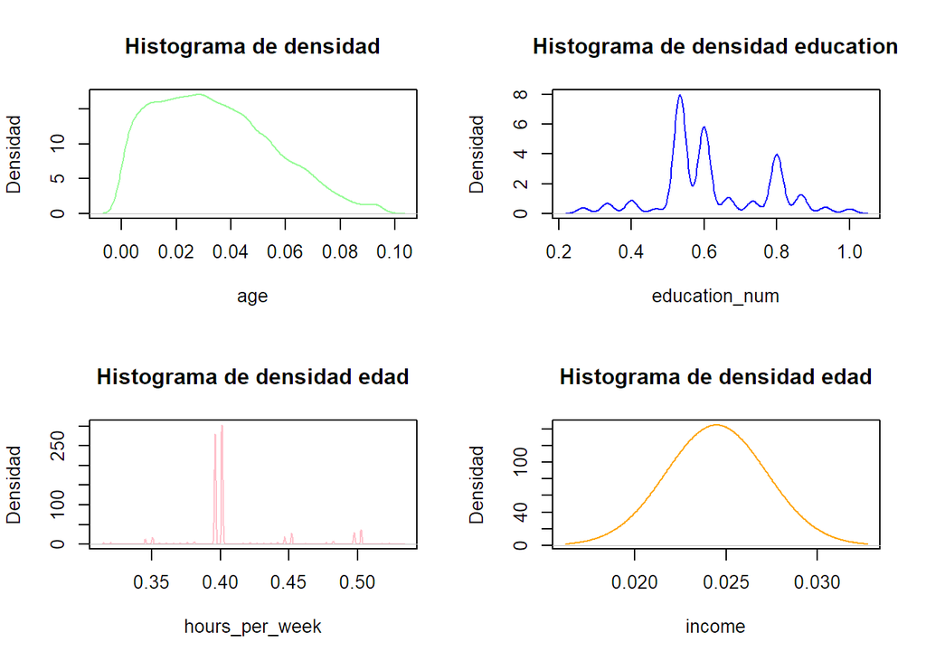

```r
densidad_age <- density(DatosCenso$age)
densidad_education <- density(DatosCenso$education_num)
densidad_hours <- density(DatosCenso$hours_per_week)
densidad_income <- density(DatosCenso$income)

par(mfrow = c(2,2)) #parámetros globales para los plots --> cómo se distribuyen los gráficos (2 filas, 2 columnas)
with(DatosCenso,
     {
       plot(densidad_age, main="Histograma de densidad", xlab="age", ylab="Densidad", col="palegreen")
       plot(densidad_education, main="Histograma de densidad education", xlab="education_num", ylab="Densidad", col="blue")
       plot(densidad_hours, main="Histograma de densidad edad", xlab="hours_per_week", ylab="Densidad", col="pink")
       plot(densidad_income, main="Histograma de densidad edad", xlab="income", ylab="Densidad", col="orange")
     })
```

## Archivo final

Una vez realizado el preprocesamiento sobre el archivo, copiad el resultado de los datos en un archivo llamado CensusIncome_clean.csv.

```r
fichero_rdo <- paste0(getwd(),"/cperezceb_CensusIncome_clean.csv")

write.csv2(DatosCenso, file = fichero_rdo, row.names = TRUE)
```